# Ciencia de Datos para Políticas Públicas

12/08/2020

## ¿Qué veremos hoy?

- ¿Qué es y por qué visualizar datos?
- Visualización con `ggplot2`
- Demostraciones
  - `Clase02_CodigoViz.R`
  - `Clase02_CodigoCovid.R`
- Ejercicio
  - `Clase02_Ejercicio.R`
- Tarea

## Antes de empezar

- ¿Alguna pregunta?

## ¿Qué es y por qué visualizar datos?

## Dos razones principales de por qué visualizar

- **Para uno**: entender los datos con el fin de guiar análisis posteriores (análisis exploratorio)
- **Para otros**: contar una historia sobre los datos y resultados con el fin de comunicar algo

## Lo que deberíamos buscar

- Mostrar los datos
- No mentir con estos
- Contar una historia (¿una relación? ¿causalidad? ¿un patrón? ¿un quiebre?)
- Reducir el ruido (o lo innecesario)
- Transmitir y convencer
- Visualizaciones deben complementar el texto y tener suficiente información para “sobrevivir por sí mismas”

## ¿Qué opinan?

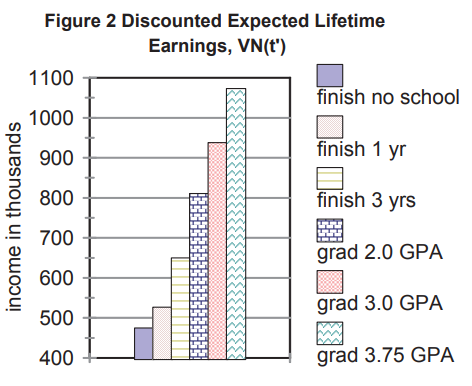

## Una idea general

- El cerebro solo puede procesar un cierto número de atributos de forma instantanea (*pre-attentive attributes*)
  - Forma, posición, color, tamaño
- Queremos buscar la variación justa en estos atributos para enfocarnos en lo que importa

## ¿Cuántos 3 hay?

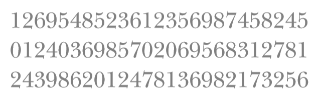

## ¿Cuántos 3 hay?

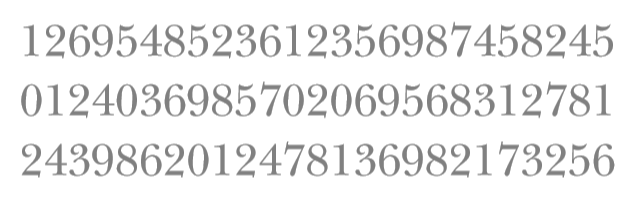

¿Y ahora?

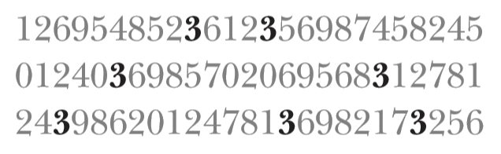

## Principios de (Edward) Tufte

https://www.edwardtufte.com/tufte/

- Muestra los datos
- Maximiza la razón datos/*tinta*
- Borra (lo más posible) la *tinta* que no corresponda a datos
- Borra *tinta* redundante
- Evita la *basura visual*
- Gráficos deben tender a ser horizontales

## Apliquemos los principios

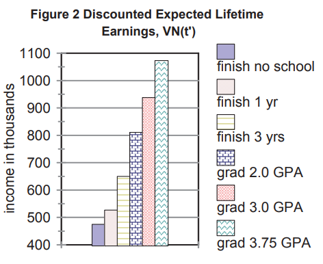

## Tratemos de hacerlo mejor

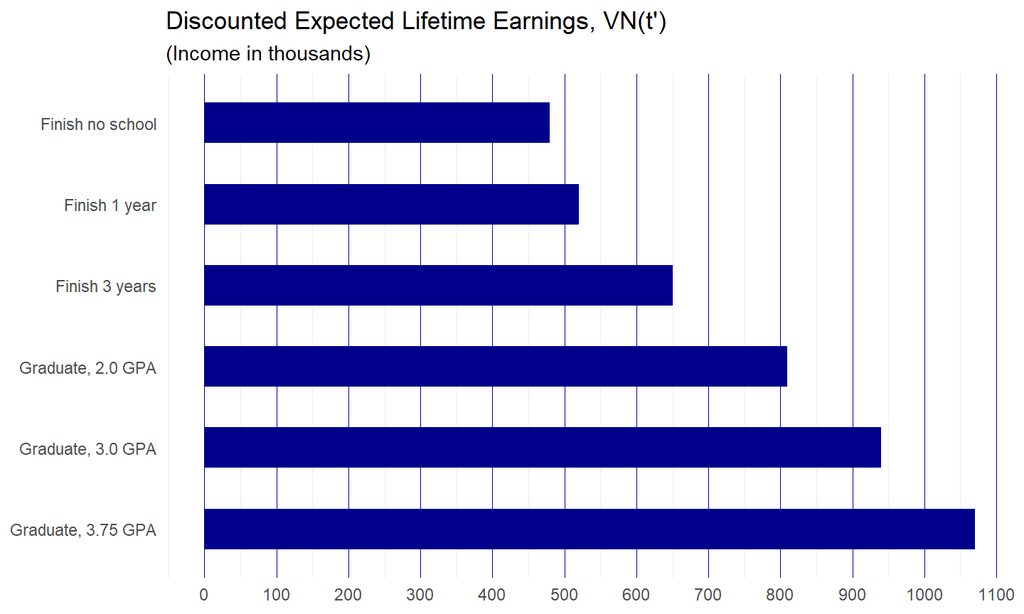

## Que hay por detrás

### `ggplot2`

```r
ggplot(datos_graf, aes(x = reorder(educ, -inc), y = inc)) +
  geom_col(width = 0.5, fill = "dark blue") +
  coord_flip() +
  labs(x = NULL, y = NULL) +
  scale_y_continuous(n.breaks = 9) +
  theme_minimal() +
  theme(panel.grid.major.y = element_blank(),
        panel.grid.minor.y = element_blank(),
        panel.grid.major.x = element_line(colour = "dark blue", size = 0.1)) +
  labs(title = "Discounted Expected Lifetime Earnings, VN(t')",
       subtitle = "(Income in thousands)")
```